# Lab1

William Kett

1/13/2020

# Lab 1

## Task 1

```r
getwd()
```

```
## [1] "C:/Users/willk/Documents/MATH4753Kett9008/Labs/Lab1"
```

## Task 2

```r
ddt = read.csv("DDT.csv") #ddt object now holds the output from the read.csv function applied to the .csv file
head(ddt) #gives the first six lines (by defualt) of the ddt file
```

```
##   RIVER MILE  SPECIES LENGTH WEIGHT DDT
## 1   FCM    5 CCATFISH   42.5    732  10
## 2   FCM    5 CCATFISH   44.0    795  16
## 3   FCM    5 CCATFISH   41.5    547  23
## 4   FCM    5 CCATFISH   39.0    465  21
## 5   FCM    5 CCATFISH   50.5   1252  50
## 6   FCM    5 CCATFISH   52.0   1255 150
```

## Task 3

1. What is the qualitative data? The qualitative variables are: River and Species
2. What is the Quantitative data? Mile, Length, Weight, and DDT (dichlordiphenyltrichloroethane or pesticides) in ppm. A fascinating side note: Anything higher than 5 ppm means that the fish are considered contaminated.
3. How many species are in the DDT data set? There are 3 species of fish in the DDT data set (if you look at the entire data set and not just the head).
4. Get a subset of the data with the specifications: [Species: ‘LMB’, and Weight > 800 mgs]

```r
with(ddt, ddt[SPECIES == "LMBASS" & WEIGHT > 800,],)
```

```
##     RIVER MILE SPECIES LENGTH WEIGHT DDT
## 141   TRM  345  LMBASS     30    856 2.2
## 144   TRM  345  LMBASS     36   1433 1.9
```

```r
#Clicker question stuff. Ignore comments below!
#LENGTH = with(ddt, LENGTH)
#LENGTH
#mean(LENGTH)
#WEIGHT = with(ddt, WEIGHT)
#WEIGHT
#sd(WEIGHT)
#plot(WEIGHT, LENGTH, col = "Red")
#v = 1:20
#v = v/20
#v
#typeof(v)
```

5. Get a subset of the data with the specifications: [River: ‘SCM’, and DDT > 4]

```r
with(ddt, ddt[RIVER == "SCM" & DDT > 4.0,],)
```

```
##    RIVER MILE  SPECIES LENGTH WEIGHT DDT
## 16   SCM    1 CCATFISH     45    984 9.1
## 17   SCM    1 CCATFISH     43    965 7.8
## 18   SCM    1 CCATFISH     45   1084 4.1
```

### Clicker Questions

> Q1: 42.8125 Q2: 376.5461 Q3: 0 (No) Q4: v/20[last element] = 1.00

## Task 4

1. Make a table of the rivers

```r
rivs=with(ddt,table(RIVER))
rivs
```

```
## RIVER
## FCM LCM SCM TRM
##   6   6   6 126
```

2. Make a color coded bar plot of the rivers

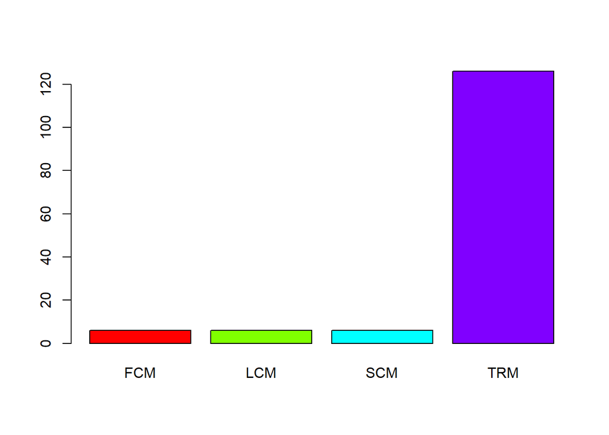

```r
barplot(rivs, col = rainbow(4))
```

3. Make a table of the rivers crossed with the species of the fish

```r
rivsp=with(ddt,table(SPECIES, RIVER))
rivsp
```

```
##            RIVER
## SPECIES     FCM LCM SCM TRM
##   CCATFISH    6   6   6  78
##   LMBASS      0   0   0  12
##   SMBUFFALO   0   0   0  36
```

4. Make a barplot of the rivers crossed with the species of the fish

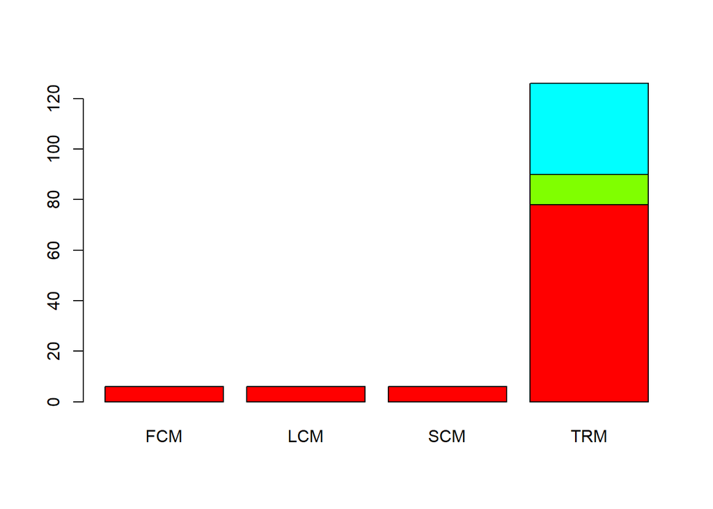

```r
barplot(rivsp, col = rainbow(4))
```

## Task 5

1. Make a pie chart of the fish SPECIES

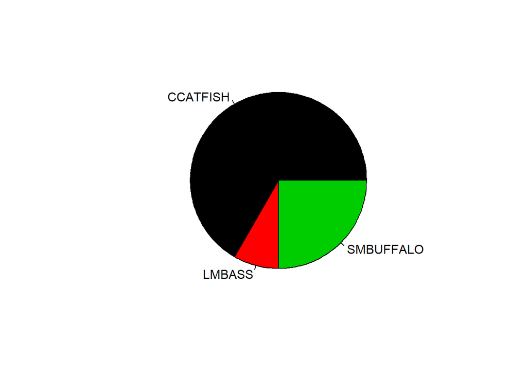

```r
sp = with(ddt, table(SPECIES))
pie(sp, col = 1:4)
```

2. Make a pie chart of the rivers

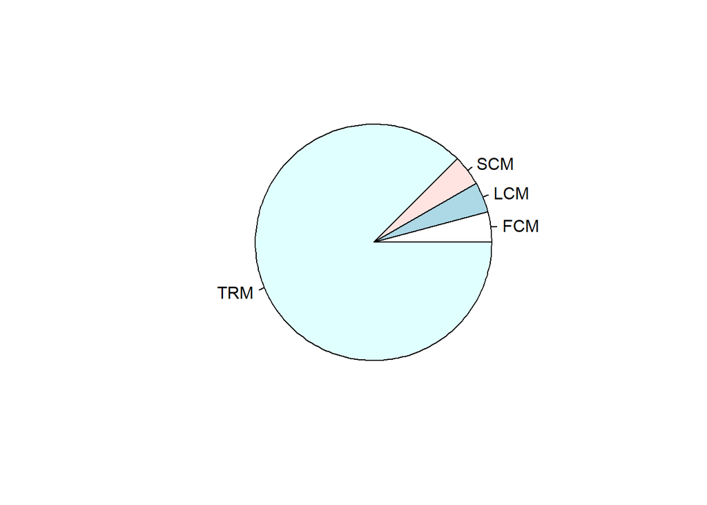

```r
rivs = with(ddt, table(RIVER))
pie(rivs)
```

## Task 6

1. Make a boxplot of the variable DDT

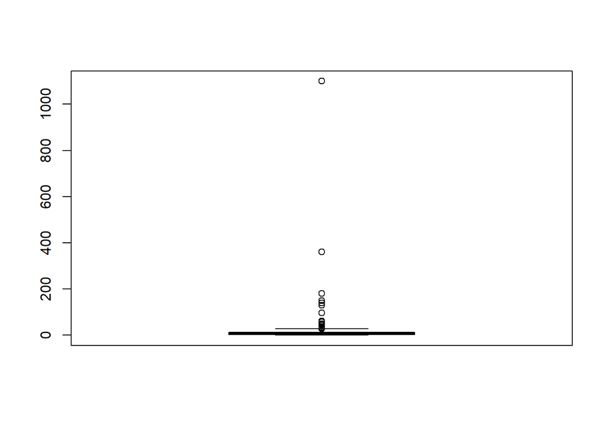

```r
ddt_data = with(ddt, DDT)
boxplot(x = ddt_data, col = "Red")
```

2. Make a boxplot of the variable WEIGHT

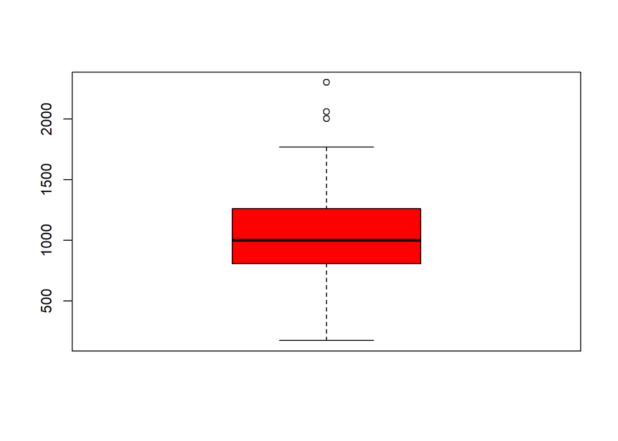

```r
wgt = with(ddt, WEIGHT)
boxplot(wgt, col = "Red", data = wgt)
boxplot(x = wgt,col = "Red")
```

3. Make a boxplot of the variable LENGTH

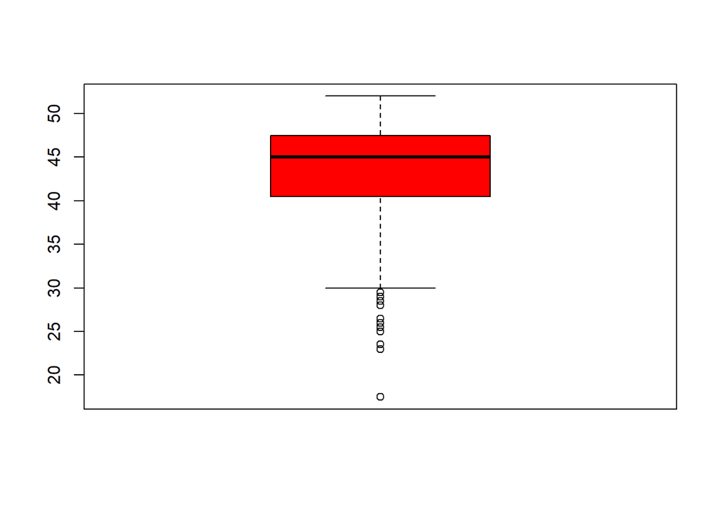

```r
len = with(ddt, LENGTH)
boxplot(len, col = "Red", data = len)
```

## Task 7

1. Make a coplot of LENGTH vs WEIGHT given RIVER

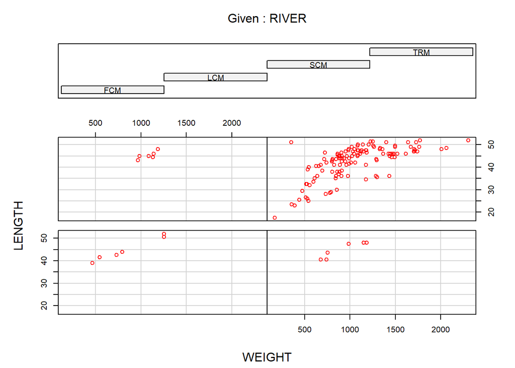

```r
coplot(LENGTH~WEIGHT|RIVER, data = ddt, col = "Red") #Using naming scheme Y vs X, the Length is the y-axis and Weight is the x-axis
```

2. Make a coplot of DDT vs WEIGHT given SPECIES

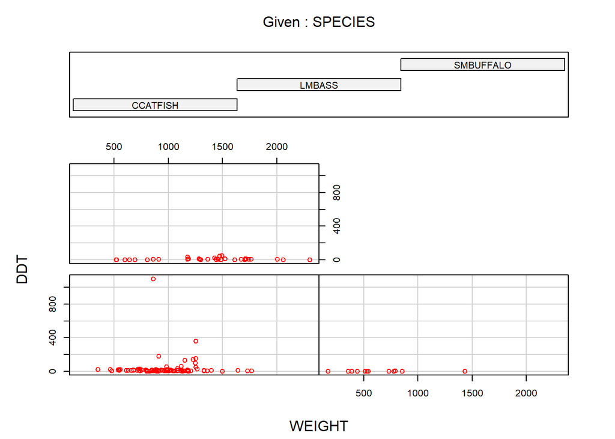

```r
coplot(DDT~WEIGHT|SPECIES, data = ddt, col = "Red")
```

## Task 8

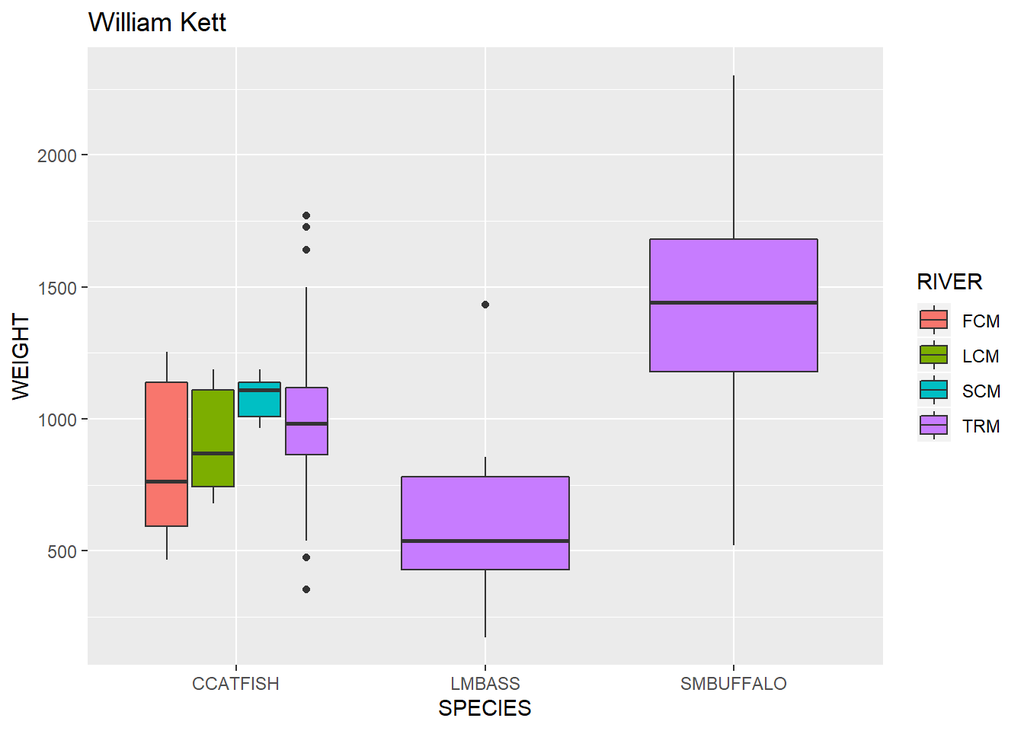

```r
#1) Use ggplot to make boxplots
library(dplyr)
library(ggplot2)
# notice how the infix %>% operator works ( the pipe )

ddt %>% filter() %>% mutate(AREA = LENGTH*WEIGHT) %>% ggplot(aes(x=SPECIES,y=WEIGHT,fill=RIVER)) + geom_boxplot() + ggtitle("William Kett")
```

2. Use ggplot to make violin plots

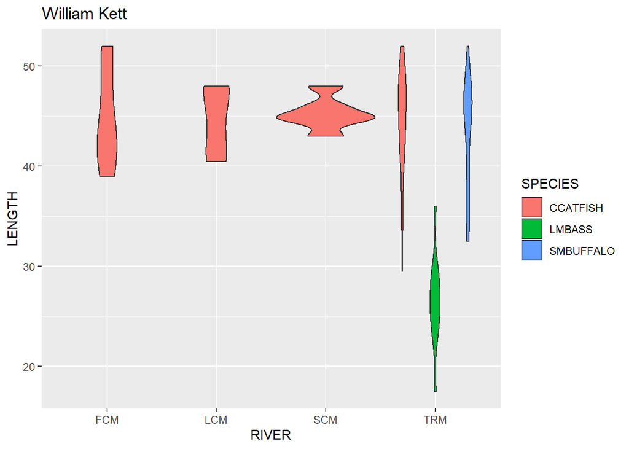

```r
ddt %>% filter() %>% mutate(AREA = LENGTH*WEIGHT) %>% ggplot(aes(x=RIVER,y=LENGTH,fill=SPECIES)) + geom_violin() + ggtitle("William Kett")
```

3) use ggplot to make scatter plots

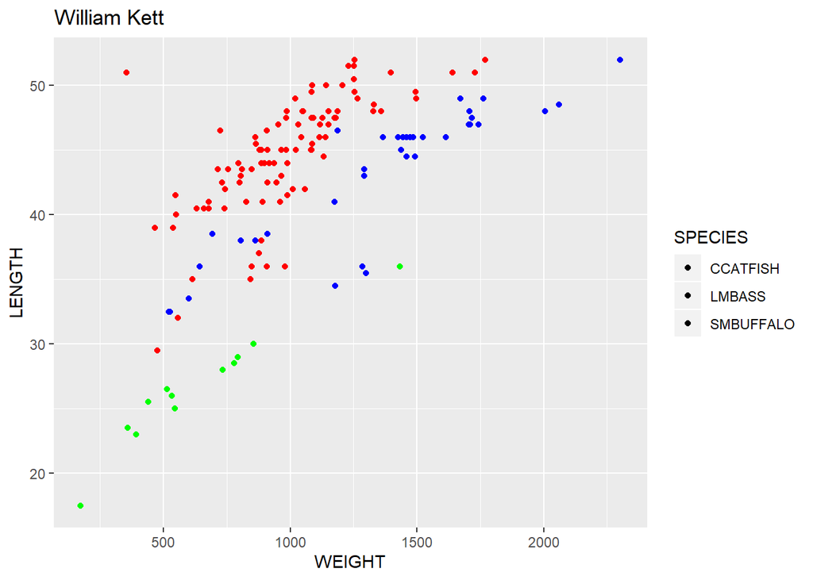

```r
pointcol = with(ddt, ifelse(SPECIES == "CCATFISH", "Red",         #if Species is "CCATFISH", point is Red
                            ifelse(SPECIES == "LMBASS", "Green",  #else if Species is "LMBASS", point is Green
                                   "Blue")))                      #else point it Blue

ddt %>% filter() %>% mutate(AREA = LENGTH*WEIGHT) %>% ggplot(aes(x=WEIGHT,y=LENGTH,fill=SPECIES)) + geom_point(col = pointcol) + ggtitle("William Kett")
```